# Project 1: Wrangling, Exploration, Visualization

SDS322E

## Data Wrangling, Exploration, Visualization

### Kayla Garza, kmg4327

#### Introduction

The two datasets I have selected are one I created titled ‘netflix_history’ that went back to August 2015 and created a set until end of July 2017 (roughly two years of data). This first set has 1,310 entries with a row at the top with rownames and had a column that determined what day of the week the date something was watch on was (monday, tuesday, etc). My second dataset is titled ‘austin_weather’ and has the weather report for each day from the same time frame as netflix_history. It includes columns/variables for avgTemp, avgHumidity and whether an event like rain or snow occured on that day. This is interesting to me because I have always used TV as an escape from my reality and I knew I watched a lot over the 6 years I have been on Netflix but its so interesting to me to see how much I actually watch. I wanted to see how the weather affected the amount I watched and if the day of the week played into anything considering I was in my first two years of high school during this time period.

```r
# read your datasets in here, e.g., with read_csv()
library(tidyverse)
netflix <- read_csv("netflix_history.csv")
weather <- read_csv("austin_weather.csv")
```

#### Tidying: Reshaping

If your datasets are tidy already, demonstrate that you can reshape data with pivot wider/longer here (e.g., untidy and then retidy). Alternatively, it may be easier to wait until the wrangling section so you can reshape your summary statistics. Note here if you are going to do this.

```r
# your tidying code (if applicable; can also wait until
# wrangling section) waiting until wrangling section
```

#### Joining/Merging

```r
# your joining code
mergedData <- left_join(netflix, weather, by = "Date")
nrow(mergedData)
```

```
## [1] 1311
```

```r
n_distinct(mergedData)
```

```
## [1] 1311
```

```r
view(mergedData)
```

There were 1311 observations in ‘netflix’ and 729 observations/rows in ‘weather’ and I joined by date to see how the weather affects the number of shows I watch in a day. No observations were dropped after the join from ‘netflix’ but rows from “weather” on days I didnt watch netflix were lost. I choose a left join because I wanted the joined data to have the same number of observations/rows as ‘netflix’ so the size of mergedData is the sme number of rows as netflix and the same number of columns of weather + 2.

#### Wrangling

```r
# your wrangling code remove unnecessary columns
mergedData <- mergedData %>% select(`Title of Show`, Date, `Day of Week`,
    TempAvgF, DewPointAvgF, HumidityAvgPercent, Events)

# create the total in a single day variable totalInOneDay <-
# mergedData %>% group_by(Date) %>% summarise(n = n())
# totalInOneDay

mergedData <- mergedData %>% group_by(Date) %>% mutate(totalInOneDay = n())
view(mergedData)
# replace all numerical values for days to strings
mergedData <- mergedData %>% mutate(`Day of Week` = str_replace_all(`Day of Week`,
    "1", "Sun"), `Day of Week` = str_replace_all(`Day of Week`,
    "2", "Mon"), `Day of Week` = str_replace_all(`Day of Week`,
    "3", "Tues"), `Day of Week` = str_replace_all(`Day of Week`,
    "4", "Wed"), `Day of Week` = str_replace_all(`Day of Week`,
    "5", "Thurs"), `Day of Week` = str_replace_all(`Day of Week`,
    "6", "Fri"), `Day of Week` = str_replace_all(`Day of Week`,
    "7", "Sat"))

# using filter, arrange, group_by and summarize to explore
# the data filter for hottest days
hotDays <- mergedData %>% filter(TempAvgF > 90)
hotDays
```

```
## # A tibble: 42 x 8
## # Groups:   Date [9]
##    `Title of Show` Date  `Day of Week` TempAvgF DewPointAvgF HumidityAvgPerc…
##    <chr>           <chr> <chr>            <dbl> <chr>        <chr>
##  1 Gilmore Girls:… 8/12… Wed                 92 68           43
##  2 The Secret Cir… 8/13… Thurs               91 67           51
##  3 The Office (U.… 7/13… Wed                 91 73           64
##  4 The Office (U.… 7/13… Wed                 91 73           64
##  5 The Office (U.… 7/13… Wed                 91 73           64
##  6 The Office (U.… 7/13… Wed                 91 73           64
##  7 The Office (U.… 7/13… Wed                 91 73           64
##  8 The Office (U.… 7/13… Wed                 91 73           64
##  9 The Office (U.… 7/13… Wed                 91 73           64
## 10 The Office (U.… 7/13… Wed                 91 73           64
## # … with 32 more rows, and 2 more variables: Events <chr>, totalInOneDay <int>
```

```r
# arrange date by greatest to least totalInOneDay
maxNum <- mergedData %>% arrange(desc(totalInOneDay))
maxNum
```

```
## # A tibble: 1,311 x 8
## # Groups:   Date [302]
##    `Title of Show` Date  `Day of Week` TempAvgF DewPointAvgF HumidityAvgPerc…
##    <chr>           <chr> <chr>            <dbl> <chr>        <chr>
##  1 The Office (U.… 7/27… Wed                 83 74           78
##  2 The Office (U.… 7/27… Wed                 83 74           78
##  3 The Office (U.… 7/27… Wed                 83 74           78
##  4 The Office (U.… 7/27… Wed                 83 74           78
##  5 The Office (U.… 7/27… Wed                 83 74           78
##  6 The Office (U.… 7/27… Wed                 83 74           78
##  7 The Office (U.… 7/27… Wed                 83 74           78
##  8 The Office (U.… 7/27… Wed                 83 74           78
##  9 The Office (U.… 7/27… Wed                 83 74           78
## 10 The Office (U.… 7/27… Wed                 83 74           78
## # … with 1,301 more rows, and 2 more variables: Events <chr>,
## #   totalInOneDay <int>
```

```r
# see how many times things were watched on each day of the
# week
mostDay <- mergedData %>% group_by(`Day of Week`) %>% summarise(TotalDay = n())
mostDay
```

```
## # A tibble: 7 x 2
##   `Day of Week` TotalDay
##   <chr>            <int>
## 1 Fri                158
## 2 Mon                172
## 3 Sat                215
## 4 Sun                226
## 5 Thurs              150
## 6 Tues               200
## 7 Wed                190
```

```r
mergedData %>% group_by(`Title of Show`) %>% summarise(n = n())
```

```
## # A tibble: 1,311 x 2
##    `Title of Show`      n
##    <chr>            <int>
##  1 : Episode 1          1
##  2 : Episode 2          1
##  3 : Episode 20         1
##  4 : Episode 21         1
##  5 : Episode 22         1
##  6 : Episode 3          1
##  7 1 Chance 2 Dance     1
##  8 1 Mile to You        1
##  9 6 Years              1
## 10 A Gift Horse         1
## # … with 1,301 more rows
```

```r
mergedData %>% group_by(TempAvgF) %>% summarise(n = n())
```

```
## # A tibble: 53 x 2
##    TempAvgF     n
##       <dbl> <int>
##  1       32     2
##  2       41    15
##  3       42    20
##  4       43    11
##  5       44     7
##  6       45    18
##  7       46    20
##  8       47     4
##  9       48    19
## 10       49    32
## # … with 43 more rows
```

```r
mergedData %>% group_by(DewPointAvgF) %>% summarise(n = n())
```

```
## # A tibble: 55 x 2
##    DewPointAvgF     n
##    <chr>        <int>
##  1 -                2
##  2 12               2
##  3 20               2
##  4 23               3
##  5 25               4
##  6 26              13
##  7 27               7
##  8 28               9
##  9 29              15
## 10 30              29
## # … with 45 more rows
```

```r
mergedData %>% group_by(HumidityAvgPercent) %>% summarise(n = n())
```

```
## # A tibble: 60 x 2
##    HumidityAvgPercent     n
##    <chr>              <int>
##  1 -                      1
##  2 28                     5
##  3 33                     3
##  4 35                     1
##  5 36                     2
##  6 37                     2
##  7 40                     3
##  8 41                     4
##  9 42                     8
## 10 43                    11
## # … with 50 more rows
```

```r
mergedData %>% group_by(Events) %>% summarise(n = n())
```

```
## # A tibble: 7 x 2
##   Events                        n
##   <chr>                     <int>
## 1 Fog                          35
## 2 Fog , Rain                   10
## 3 Fog , Rain , Thunderstorm    47
## 4 Rain                        238
## 5 Rain , Thunderstorm         116
## 6 Thunderstorm                 23
## 7 <NA>                        842
```

This is the main part of the wrangling section. I used all 6 core dplyr functions to explore my data. I mutated my dataset to add a column that counted the number of shows/movies I watched in a day, as well as using mutate to ‘rename’ the days of the week. In the end, I went through my data to find the entries on the hottest days of the roughly two year time frame, I found which day I watched the most on and by how much, and I looked into seeing which day of the week I watched the most netflix on. The last couple lines of code are counting each variable and its frequency and I find it intersting that besides only watching every entry only once, there were more more foggy days (35) than thunderstorms alone (23) that I watched netflix.

```r
# your wrangling code
table1 <- mergedData %>% group_by(totalInOneDay, `Day of Week`) %>%
    summarise(avgTemp = mean(TempAvgF), maxDew = max(DewPointAvgF),
        stdHumidity = sd(HumidityAvgPercent), count = n(), se = stdHumidity/sqrt(count))
table1
```

```
## # A tibble: 84 x 7
## # Groups:   totalInOneDay [17]
##    totalInOneDay `Day of Week` avgTemp maxDew stdHumidity count    se
##            <int> <chr>           <dbl> <chr>        <dbl> <int> <dbl>
##  1             1 Fri              80.7 74            9.85     9  3.28
##  2             1 Mon              78.9 74           11.6      8  4.11
##  3             1 Sat              74.4 74           11.7     16  2.93
##  4             1 Sun              69.2 73           13.5     13  3.76
##  5             1 Thurs            78.5 73           11.4     11  3.42
##  6             1 Tues             76.8 72           NA       12 NA
##  7             1 Wed              82   76           12.3     11  3.71
##  8             2 Fri              86.3 73            5.24     6  2.14
##  9             2 Mon              78.1 73           12.3     22  2.62
## 10             2 Sat              83.5 72            5.29     8  1.87
## # … with 74 more rows
```

```r
mergedData %>% summarise_all(function(x) sum(is.na(x)))
```

```
## # A tibble: 302 x 8
##    Date  `Title of Show` `Day of Week` TempAvgF DewPointAvgF HumidityAvgPerc…
##    <chr>           <int>         <int>    <int>        <int>            <int>
##  1 1/1/…               0             0        0            0                0
##  2 1/10…               0             0        0            0                0
##  3 1/11…               0             0        0            0                0
##  4 1/13…               0             0        0            0                0
##  5 1/14…               0             0        0            0                0
##  6 1/15…               0             0        0            0                0
##  7 1/16…               0             0        0            0                0
##  8 1/17…               0             0        0            0                0
##  9 1/18…               0             0        0            0                0
## 10 1/20…               0             0        0            0                0
## # … with 292 more rows, and 2 more variables: Events <int>, totalInOneDay <int>
```

In this section I used dplyr to create summary statistics for each of my numeric variables and summed up all the NA’s in each column of my dataset.

```r
# your wrangling code
library(gt)
table1 %>% group_by(`Day of Week`) %>% gt %>% tab_header(title = md("**Summary Statistics**"),
    subtitle = md("A table of my `mergedData` summary statistics")) %>%
    tab_spanner(label = "Variables", columns = c("avgTemp", "maxDew",
        "stdHumidity", "count", "se"))
```

**Summary Statistics**

A table of my `mergedData` summary statistics

| totalInOneDay | Variables avgTemp | Variables maxDew | Variables stdHumidity | Variables count | Variables se |
| --- | --- | --- | --- | --- | --- |
| Fri |  |  |  |  |  |
| 1 | 80.66667 | 74 | 9.8488578 | 9 | 3.2829526 |
| 2 | 86.33333 | 73 | 5.2408651 | 6 | 2.1395742 |
| 3 | 82.50000 | 69 | 0.5477226 | 6 | 0.2236068 |
| 4 | 68.00000 | 60 | 2.2478059 | 20 | 0.5026247 |
| 5 | 72.33333 | 75 | 14.0534693 | 30 | 2.5658007 |
| 6 | 46.00000 | 29 | 0.0000000 | 6 | 0.0000000 |
| 7 | 59.00000 | 39 | 0.0000000 | 7 | 0.0000000 |
| 8 | 57.00000 | 53 | 18.0739223 | 16 | 4.5184806 |
| 9 | 69.66667 | 71 | 10.0880737 | 27 | 1.9414507 |
| 14 | 82.00000 | 71 | 0.0000000 | 14 | 0.0000000 |
| 17 | 91.00000 | 64 | 0.0000000 | 17 | 0.0000000 |
| Mon |  |  |  |  |  |
| 1 | 78.87500 | 74 | 11.6181816 | 8 | 4.1076475 |
| 2 | 78.09091 | 73 | 12.2830965 | 22 | 2.6187650 |
| 3 | 72.85714 | 74 | 8.1740006 | 21 | 1.7837132 |
| 4 | 65.33333 | 71 | 0.4923660 | 12 | 0.1421338 |
| 5 | 70.00000 | 68 | 7.0524352 | 20 | 1.5769724 |
| 6 | 48.00000 | 36 | 0.0000000 | 6 | 0.0000000 |
| 7 | 78.00000 | 68 | 0.0000000 | 7 | 0.0000000 |
| 8 | 86.00000 | 67 | 0.0000000 | 8 | 0.0000000 |
| 9 | 86.00000 | 74 | 17.4928557 | 18 | 4.1231056 |
| 11 | 74.00000 | 72 | 0.0000000 | 11 | 0.0000000 |
| 12 | 87.00000 | 70 | 0.0000000 | 24 | 0.0000000 |
| 15 | 41.00000 | 30 | 0.0000000 | 15 | 0.0000000 |
| Sat |  |  |  |  |  |
| 1 | 74.43750 | 74 | 11.7187528 | 16 | 2.9296882 |
| 2 | 83.50000 | 72 | 5.2915026 | 8 | 1.8708287 |
| 3 | 71.00000 | 74 | 12.8242722 | 24 | 2.6177436 |
| 4 | 83.00000 | 72 | 0.0000000 | 4 | 0.0000000 |

[output cut: 61 more lines]

```r
table2 <- table1 %>% pivot_longer(c("stdHumidity", "se"), names_to = "Statistical Vars",
    values_to = "Values")
table2
```

```
## # A tibble: 168 x 7
## # Groups:   totalInOneDay [17]
##    totalInOneDay `Day of Week` avgTemp maxDew count `Statistical Vars` Values
##            <int> <chr>           <dbl> <chr>  <int> <chr>               <dbl>
##  1             1 Fri              80.7 74         9 stdHumidity          9.85
##  2             1 Fri              80.7 74         9 se                   3.28
##  3             1 Mon              78.9 74         8 stdHumidity         11.6
##  4             1 Mon              78.9 74         8 se                   4.11
##  5             1 Sat              74.4 74        16 stdHumidity         11.7
##  6             1 Sat              74.4 74        16 se                   2.93
##  7             1 Sun              69.2 73        13 stdHumidity         13.5
##  8             1 Sun              69.2 73        13 se                   3.76
##  9             1 Thurs            78.5 73        11 stdHumidity         11.4
## 10             1 Thurs            78.5 73        11 se                   3.42
## # … with 158 more rows
```

In this section I made a couple of tables with the data from the previous section. The ‘gt’ function made the table look great and I was able to ‘pivot_longer’ to group the variables that depend on standard deviation (sd).

#### Visualizing

Create 3 effective, polished plots with ggplot (30 pts)

Each plot should have at least 2 geometry layers and at least 2 aesthetic mappings Each plot should have a title and clean labeling for all mappings Modify the default theme and scales at least once per plot For at least one plot, add more tick marks (x, y, or both) than are given by default For at least one plot, use the stat=“summary” function Write a supporting paragraph (for each plot) describing what the plot depicts and any relationships/trends that are apparent (9 pts)

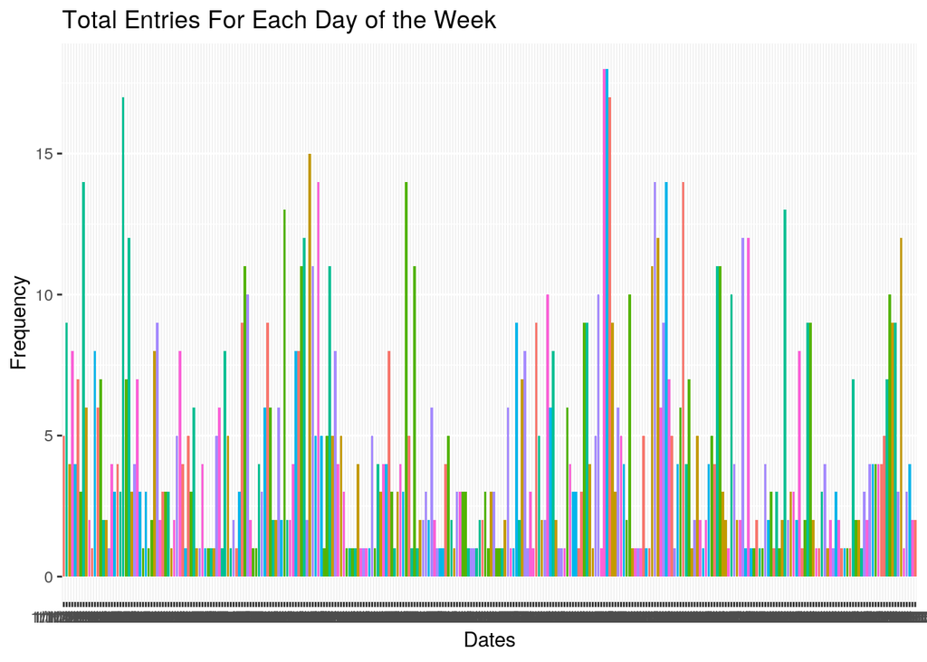

```r
# your plot 1
mergedData %>% ggplot(aes(Date, totalInOneDay, fill = `Day of Week`)) +
    geom_bar(stat = "summary") + labs(x = "Dates") + ggtitle("Total Entries For Each Day of the Week") +
    guides(fill = FALSE) + scale_y_continuous(breaks = seq(0,
    20, 5), name = "Frequency") + theme(legend.position = "right")
```

Plot 1 is a bar plot to see how the frequency/amount of entries in a single day correspond to the dates and each color is a different day of the week. From this plot we see that most days I watched 5 or less entries.

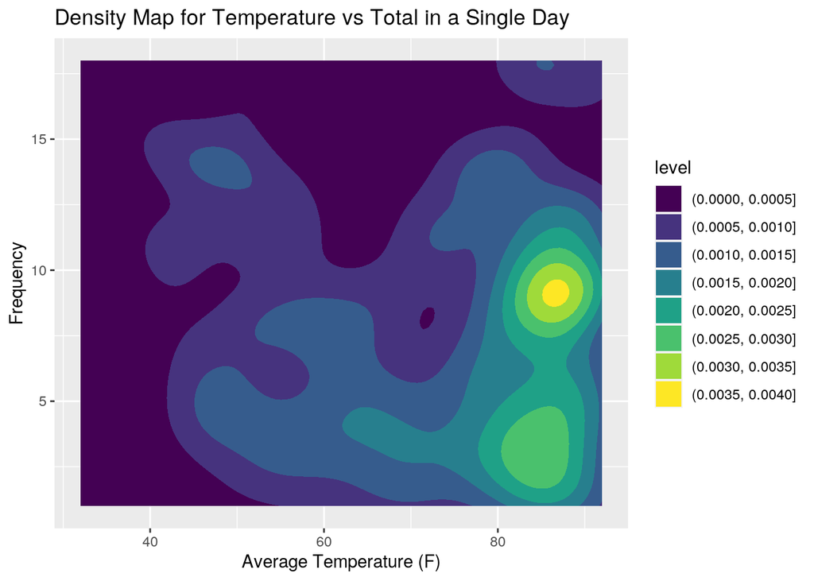

```r
# your plot 2
mergedData %>% ggplot() + geom_density2d_filled(aes(TempAvgF,
    totalInOneDay)) + labs(x = "Average Temperature (F)", y = "Frequency") +
    ggtitle("Density Map for Temperature vs Total in a Single Day")
```

Plot 2 is a density map correlating temperature and the frequency of entries in a single day. From this we see that the highest density is on days with higher temps and about 10 entries in a day. We see that the lowest density are in lower temps regardless of frequency.

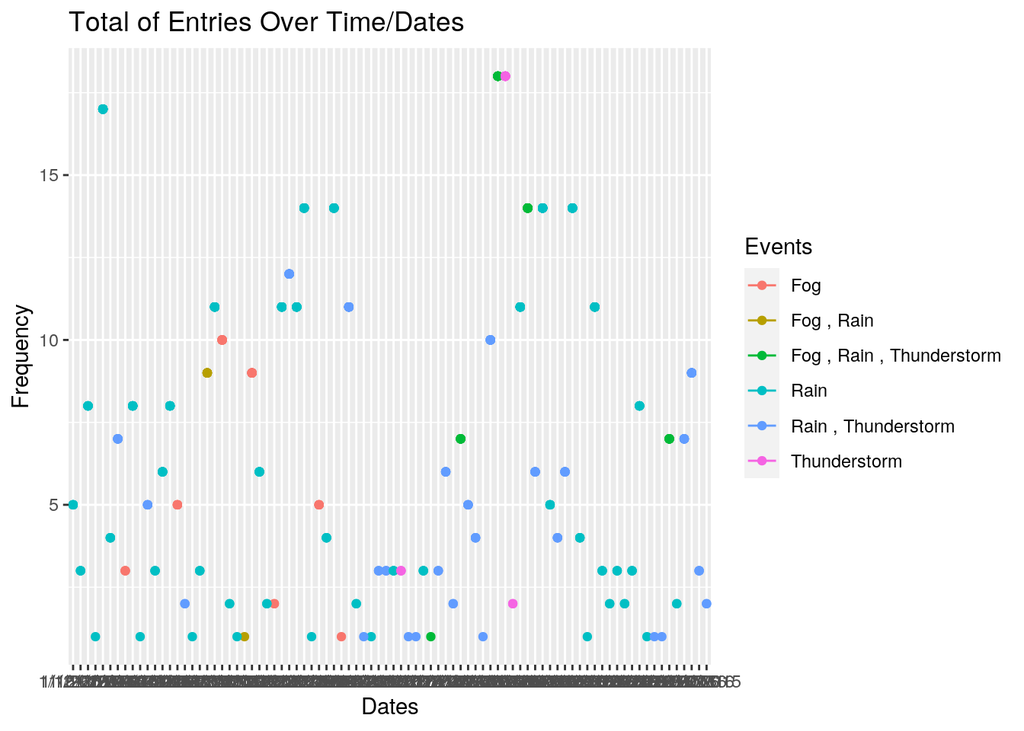

```r
# your plot 3
mergedData %>% drop_na(Events) %>% ggplot(aes(Date, totalInOneDay,
    color = Events)) + geom_point(inherit.aes = TRUE) + ggtitle("Total of Entries Over Time/Dates") +
    labs(x = "Dates", y = "Frequency") + geom_line(aes(Date,
    totalInOneDay, color = Events)) + theme(legend.position = "right")
```

#### Concluding Remarks

I really enjoyed this project and loved looking back in time in my netflix history and its crazy to see what I was watching when I first got my own netflix profile off my family one that started in 2012. I’m intrigued to see more viewing histories like hulu and disney+ as well!